# 2022 Rating Curves

Jake Cavaiani, Karen Jorgenson

11/7/2022

The purpose of this script is to read in pressure transducer data from 2022 and generate rating curves to ultimately generate predicted continuous discharge records throughout the whole season.

Read in most updated merged files from each site from the google drive (DoD Project->2022 AK sensors->Discharge->site->“merged_date_file” )

### ALL Sites

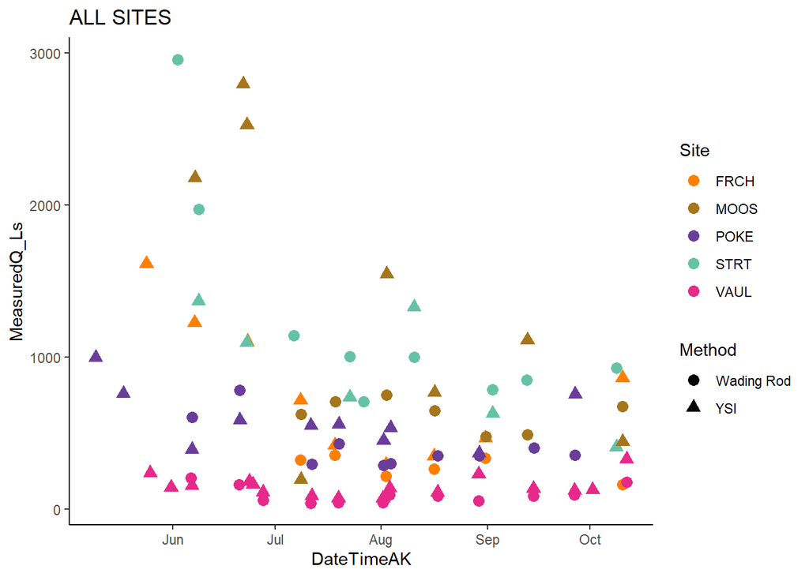

```r
# Import data from google drive #
discharge.2022 <- "https://docs.google.com/spreadsheets/d/e/2PACX-1vQR6HHHDpnxc6DmNHfdNLR9-dgDHR5Imt0Ve4_t2DzIF18_8D3O2da5zcWQzJUSoFQfaetPZDeXZ610/pub?gid=0&single=true&output=csv"
QSummary.2022 <- read.csv(url(discharge.2022))

### Format Time ###
QSummary.2022$Date <- mdy(QSummary.2022$Date)
QSummary.2022$DateTimeAK <- as.POSIXct(paste(QSummary.2022$Date, QSummary.2022$Time), format = "%Y-%m-%d %H:%M", tz = "America/Anchorage")
QSummary.2022$DateTimeAK <- lubridate::round_date(QSummary.2022$DateTimeAK, "5 minutes")

### ALL Sites ###
QSummary.2022 %>% ggplot() +
  geom_point(aes(x=DateTimeAK, y=MeasuredQ_Ls, color=Site, shape=Method), size=3) +
  theme_classic() +
  scale_color_manual(values=c("#FF7F00","#A6761D", "#6A3D9A", "#66C2A5", "#E7298A")) + ggtitle("ALL SITES")
```

Here is all the discrete discharge measurements for 2022

Eielson atmospheric pressure data will be used to fill gaps in air pressure.

```r
eielson.atmo.2022.url <- "https://docs.google.com/spreadsheets/d/e/2PACX-1vQjJbkVdOseFUsTFMDXaHRoKkPiFt6Uvc-9R3tkFZxKFjqSmPPgZzexdbhezBr_qYgGUdVN6ywYR28c/pub?output=csv"

eielson.atmo.2022 <- read.csv(url(eielson.atmo.2022.url), skip = 6)
eielson.atmo.2022 <- eielson.atmo.2022[-1,]

names(eielson.atmo.2022) <- c("Site", "DateTimeAK", "sea_level_pressure", "AirPressure")

eielson.atmo.2022$DateTimeAK <- mdy_hm(eielson.atmo.2022$DateTimeAK)

# Correct time zone
eielson.atmo.2022$DateTimeAK <- eielson.atmo.2022$DateTimeAK - 28800
eielson.atmo.2022$DateTimeAK <- force_tz(eielson.atmo.2022$DateTimeAK, tz = "America/Anchorage")

eielson.atmo.2022$DateTimeAK <- lubridate::round_date(eielson.atmo.2022$DateTimeAK, "5 minutes")

eielson.atmo.2022$AirPressure <- as.numeric(eielson.atmo.2022$AirPressure)
eielson.atmo.2022$sea_level_pressure <- as.numeric(eielson.atmo.2022$sea_level_pressure)

# Convert to kPa
eielson.atmo.2022$sea_level_pressure_kpa <- eielson.atmo.2022$sea_level_pressure*3.38639
```

NEON air pressure data

```r
#NEON_air <-loadByProduct(dpID = "DP1.00004.001", site=c("BONA"),startdate="2022-05", enddate="2022-11")
#NEON_bp <- NEON_air$BP_1min %>% filter(staPresFinalQF != 1)
#write.csv(NEON_bp, "NEON_bp_2022.csv")

NEON_url <- "https://docs.google.com/spreadsheets/d/e/2PACX-1vRxjgfFQQidmFmjWZX1_7wo3g1tbrpyImxGz3jqGczte0wGOdIi8265-2Jbj2qXn7e9N1ymti3rQEnU/pub?output=csv"
NEON_bp <- read.csv(url(NEON_url))

NEON_bp$DateTimeAK <- as.POSIXct(NEON_bp$startDateTime, format = "%Y-%m-%d %H:%M", tz = "GMT")
attr(NEON_bp$DateTimeAK, "tzone") <- "America/Anchorage"

## Round time to 5 minutes and take average
NEON_bp$DateTimeAK <- lubridate::round_date(NEON_bp$DateTimeAK, "5 minutes")
NEON_bp <- NEON_bp %>% group_by(DateTimeAK) %>% summarise(bp_sea = mean(corPres, na.rm = TRUE))

# Fill gaps in data
DateTimeFill <- data.frame(DateTimeAK = seq(ymd_hm("
2022-05-01 00:00", tz = "America/Anchorage"),ymd_hm("2022-10-15 00:00", tz = "America/Anchorage"), by = '15 mins'))
NEON_bp <- full_join(NEON_bp, DateTimeFill)
```

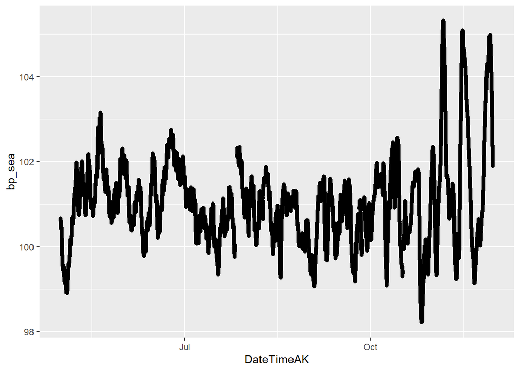

```r
NEON_bp <- NEON_bp[order(NEON_bp$DateTimeAK),]
NEON_bp$bp_sea <- na_kalman(NEON_bp$bp_sea, maxgap = 10)

NEON_bp %>% #filter(DateTimeAK > "2022-06-01" & DateTimeAK < "2022-07-01") %>%
  ggplot(aes(DateTimeAK, bp_sea)) + geom_point()
```

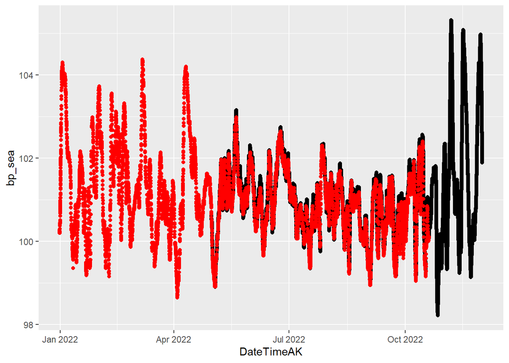

```r
# Compare NEON and Eielson sea level pressure
NEON_bp %>% ggplot(aes(DateTimeAK, bp_sea)) + geom_point() + geom_point(data = eielson.atmo.2022, aes(DateTimeAK, sea_level_pressure_kpa), color = "red")
```

```r
# They are similar, so I will fill in the gaps in NEON with Eielson
# Fill in gaps
Air_combo <- left_join(NEON_bp, eielson.atmo.2022)
```

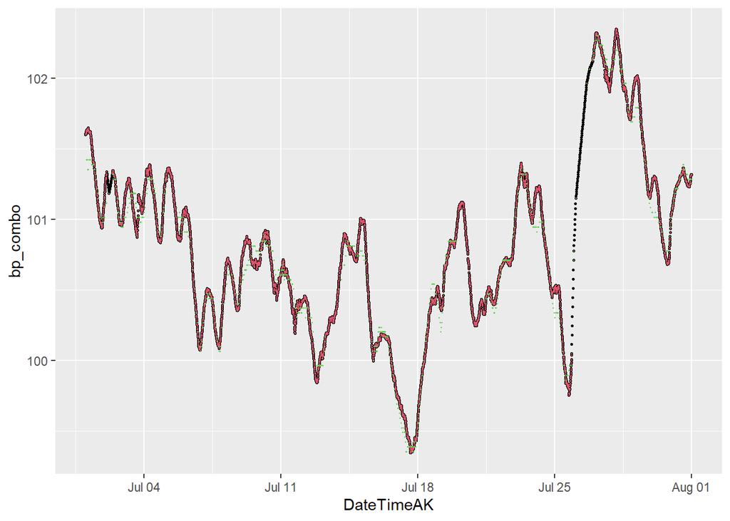

```r
Air_combo <- Air_combo %>% mutate(bp_combo = ifelse(bp_sea %in% NA, sea_level_pressure_kpa, bp_sea))

Air_combo$bp_combo <- na_kalman(Air_combo$bp_combo, type = "level")

Air_combo %>% filter(DateTimeAK > "2022-07-01" & DateTimeAK < "2022-08-01") %>%
  ggplot(aes(DateTimeAK, bp_combo)) + geom_point(size = 0.5) + geom_point(aes(DateTimeAK, bp_sea), color = 2, size = 0.2) + geom_point(aes(DateTimeAK, sea_level_pressure_kpa), color = 3, size = 0.2)# units are kilopascals, corrected to sea level
```

```r
# Convert to elevation using formula from "Barometric Pressure conversion for DO calibration.xls"
# MOOS elevation is 574 feet
# POKE 760.96 ft
# STRT 820 ft
# FRCH 601 ft
# VAUL 688.8 ft

# MOOS
Air_combo$AirPressureCorrectedMOOS <- (Air_combo$bp_combo*7.50062 - (2.5*574/100)) / 7.50062

# POKE
Air_combo$AirPressureCorrectedPOKE <- (Air_combo$bp_combo*7.50062 - (2.5*760.96/100)) / 7.50062

# STRT
Air_combo$AirPressureCorrectedSTRT <- (Air_combo$bp_combo*7.50062 - (2.5*820/100)) / 7.50062

# FRCH
Air_combo$AirPressureCorrectedFRCH <- (Air_combo$bp_combo*7.50062 - (2.5*601/100)) / 7.50062

# VAUL
Air_combo$AirPressureCorrectedVAUL <- (Air_combo$bp_combo*7.50062 - (2.5*688.8/100)) / 7.50062
```

### MOOS

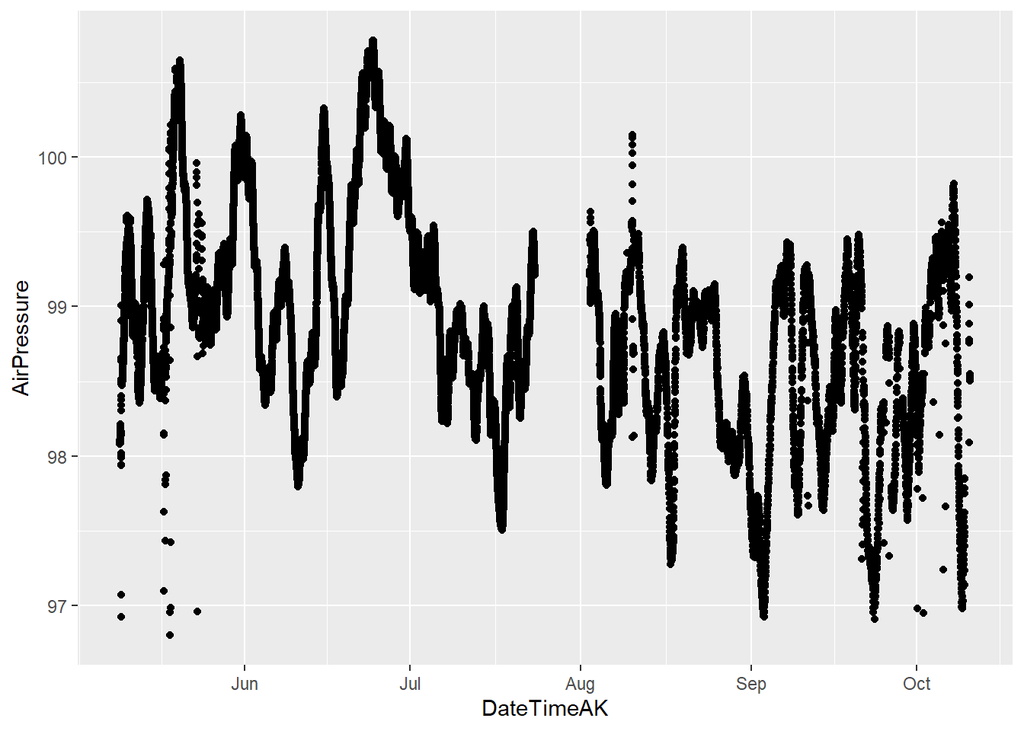

```r
# Load in water pressure data
# urls
moos.atmo.2022.url <- "https://docs.google.com/spreadsheets/d/e/2PACX-1vQ7QMNWjVX1R43qflIW7lVqkj7wRHouhgQhWK76kfR8zK-UZg9bFSm92ccPy8T0luhFHKwsLNQQjA56/pub?output=csv"
moos.stream.one.2022.url <- "https://docs.google.com/spreadsheets/d/e/2PACX-1vRo04g32Yr3DsZbXQiw6VTPfgWuWq5csh1VhxfMy3IT3U6OkJOGvTlofjXwFfugiaRVJ34pPnOUZ3te/pub?output=csv"
moos.stream.two.2022.url <- "https://docs.google.com/spreadsheets/d/e/2PACX-1vQRXmAtoP_7I2RYEDZrdCT1LDyD8W3Thjst549srxdlWDMUYUyBjiGABd8pgtZE9Efa8b4Vgb3qtyoc/pub?output=csv"

# load in data
moos.atmo.2022 <- read.csv(url(moos.atmo.2022.url), skip = 1)
moos.stream.one.2022 <- read.csv(url(moos.stream.one.2022.url), skip = 1)
moos.stream.two.2022 <- read.csv(url(moos.stream.two.2022.url), skip = 1)

# cleaning df to be able to interpret and merge
moos.atmo.2022 <- moos.atmo.2022[, -c(5:11)] # removing columns that aren't date/abs pressure and temp
moos.stream.one.2022 <- moos.stream.one.2022[, -c(5:13)] # removing columns that aren't date/abs pressure and temp
moos.stream.two.2022 <- moos.stream.two.2022[, -c(5:13)] # removing columns that arent date/abs pressure and temp

# changing datetime to AK time
moos.atmo.2022$DateTimeAK <- mdy_hms(moos.atmo.2022$Date.Time..GMT.08.00)

moos.stream.one.2022$DateTimeAK <- mdy_hms(moos.stream.one.2022$Date.Time..GMT.08.00)

moos.stream.two.2022$DateTimeAK <- mdy_hms(moos.stream.two.2022$Date.Time..GMT.08.00)

moos.stream.two.2022$DateTimeAK <- force_tz(moos.stream.two.2022$DateTimeAK, tzone = "America/Anchorage")

moos.stream.one.2022$DateTimeAK <- force_tz(moos.stream.one.2022$DateTimeAK, tzone = "America/Anchorage")

moos.atmo.2022$DateTimeAK <- force_tz(moos.atmo.2022$DateTimeAK, tzone = "America/Anchorage")

# round date to 5 minute intervals
#moos.atmo.2022$DateTimeAK <- lubridate::round_date(moos.atmo.2022$DateTimeAK, "5 minutes")
moos.stream.one.2022$DateTimeAK <- lubridate::round_date(moos.stream.one.2022$DateTimeAK, "5 minutes")
moos.stream.two.2022$DateTimeAK <- lubridate::round_date(moos.stream.two.2022$DateTimeAK, "5 minutes")

# changing the names

# cleaning off original datetime
moos.atmo.2022 <- moos.atmo.2022[, -c(2)] # removing columns that aren't date/abs pressure and temp
moos.stream.one.2022 <- moos.stream.one.2022[, -c(2)] # removing columns that aren't date/abs pressure and temp
moos.stream.two.2022 <- moos.stream.two.2022[, -c(2)] # removing columns that arent

names(moos.atmo.2022) <- c("Site", "AirPressure", "TempC", "DateTimeAK")

names(moos.stream.one.2022) <- c("Site", "WaterPressure", "TempC", "DateTimeAK")

names(moos.stream.two.2022) <- c("Site", "WaterPressure", "TempC",  "DateTimeAK")


moos.atmo.2022 %>% filter(AirPressure > 96.8) %>% ggplot(aes(x = DateTimeAK, y = AirPressure)) +
  geom_point()
```

This is the raw atmospheric pressure that is located at MOOS. I am going to clean this up a little bit:

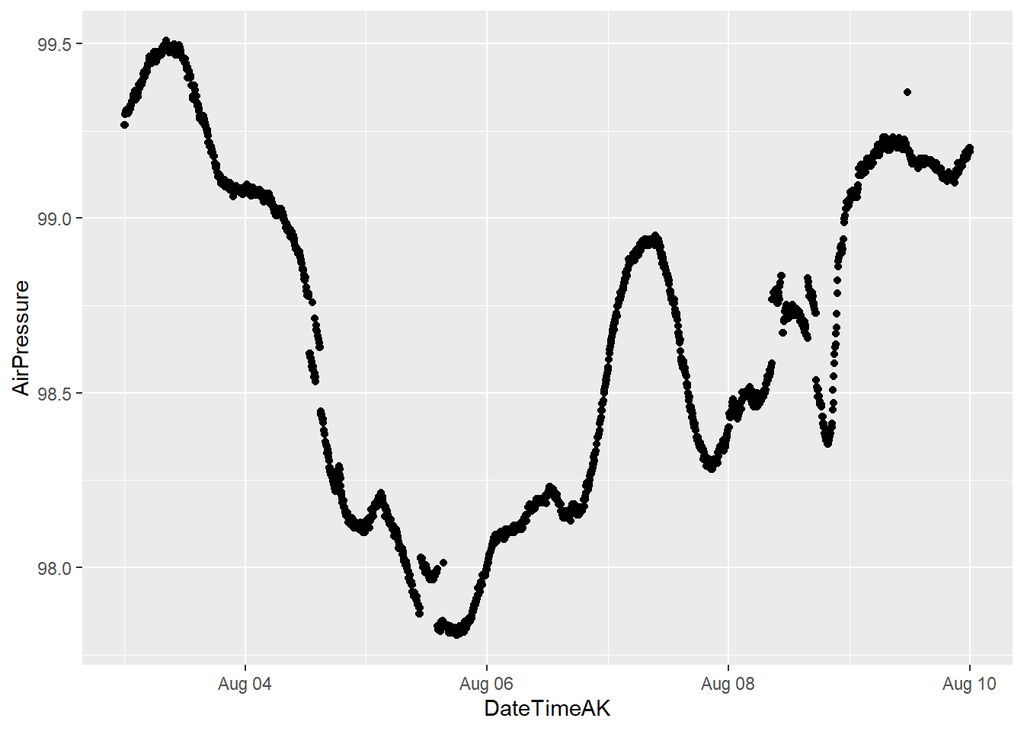

```r
# cleaning erroneous points
moos.atmo.2022 <- moos.atmo.2022 %>%
  mutate(across(c(AirPressure),
                ~ifelse(DateTimeAK <= "2022-06-01" & AirPressure < 97.5, NA, .))) %>% filter(AirPressure > 96.5)

moos.atmo.2022 <- moos.atmo.2022 %>%
  mutate(across(c(AirPressure),
                ~ifelse(DateTimeAK >= "2022-05-15" & DateTimeAK <= "2022-05-20" & AirPressure < 98.2, NA, .)))

moos.atmo.2022 <- moos.atmo.2022 %>%
  mutate(across(c(AirPressure),
                ~ifelse(DateTimeAK >= "2022-05-18" & DateTimeAK <= "2022-05-20" & AirPressure < 99.1, NA, .)))

moos.atmo.2022 <- moos.atmo.2022 %>%
  mutate(across(c(AirPressure),
                ~ifelse(DateTimeAK >= "2022-08-10" & DateTimeAK <= "2022-08-12" & AirPressure > 99.5, NA, .)))

moos.atmo.2022 <- moos.atmo.2022 %>%
  mutate(across(c(AirPressure),
                ~ifelse(DateTimeAK >= "2022-08-10" & DateTimeAK <= "2022-08-12" & AirPressure < 99, NA, .)))

moos.atmo.2022 <- moos.atmo.2022 %>%
  mutate(across(c(AirPressure),
                ~ifelse(DateTimeAK >= "2022-08-10" & AirPressure < 96.8, NA, .)))

moos.atmo.2022 <- moos.atmo.2022 %>% filter(DateTimeAK <= "2022-10-10 12:30:00") %>% mutate(across(c(AirPressure),
                ~ifelse(DateTimeAK >= "2022-10-3"& DateTimeAK <= "2022-10-8" & AirPressure < 98.5, NA, .)))

moos.atmo.2022 <- moos.atmo.2022 %>% mutate(across(c(AirPressure),
                ~ifelse(DateTimeAK >= "2022-10-2"& DateTimeAK <= "2022-10-3" & AirPressure < 98, NA, .))) %>% filter(DateTimeAK < "2022-08-01" | DateTimeAK > "2022-08-02 19:00")


moos.atmo.2022 %>% filter(DateTimeAK <= "2022-08-10" & DateTimeAK >= "2022-08-03") %>%
  ggplot(aes(x = DateTimeAK, y = AirPressure)) +
  geom_point()
```

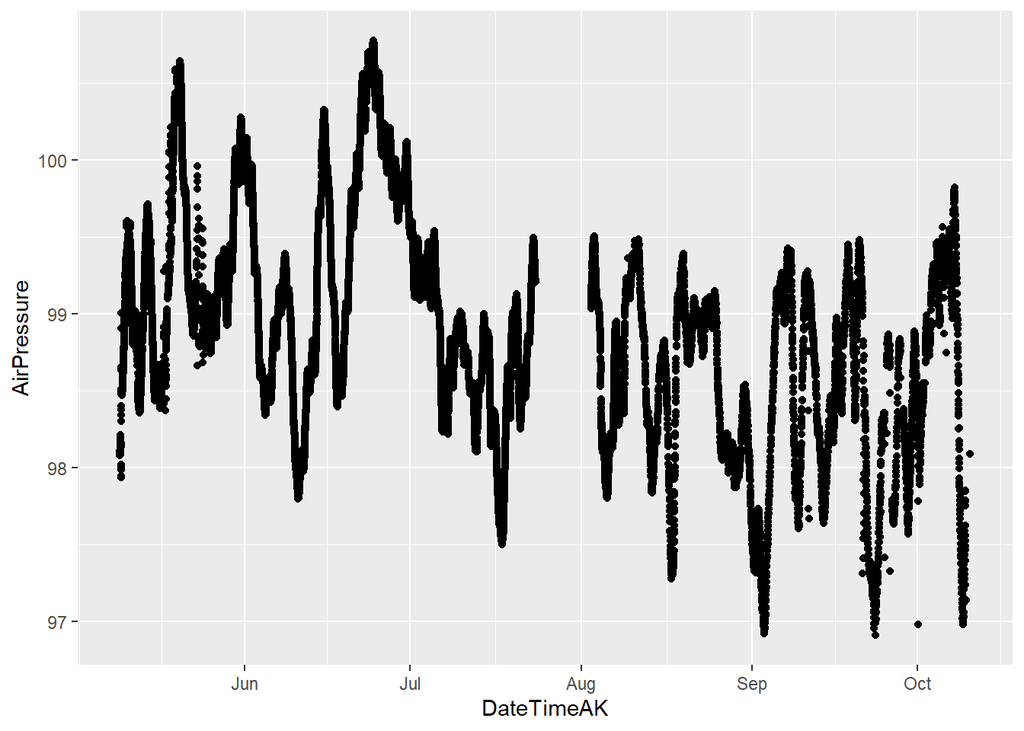

```r
moos.atmo.2022 %>% ggplot(aes(x = DateTimeAK, y = AirPressure)) +
  geom_point()
```

This is a little better. Here is the uncorrected air pressure comparison between Eielson and MOOS:

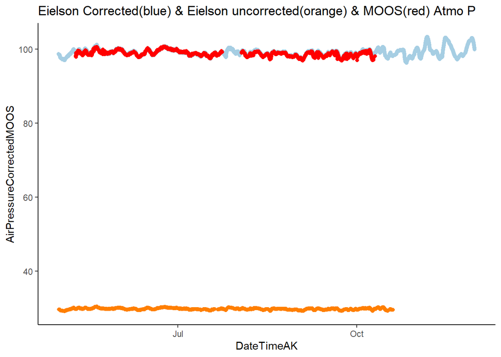

```r
moos.atmo.2022.compare <- moos.atmo.2022

atmo.pt.2022.1 <- left_join(Air_combo, moos.atmo.2022.compare, by = "DateTimeAK")

atmo.pt.2022.1 %>% #filter(DateTimeAK <= "2022-08-10" & DateTimeAK >= "2022-08-02") %>%
  ggplot(aes(x = DateTimeAK, y = AirPressureCorrectedMOOS)) +
  geom_point(aes(x=DateTimeAK, y=AirPressureCorrectedMOOS), color="#A6CEE3") +
  geom_point(aes(x=DateTimeAK, y=AirPressure.x), color="#FF7F00") +
  geom_point(aes(x=DateTimeAK, y=AirPressure.y), color = "red") +
  theme_classic() +
  ggtitle("Eielson Corrected(blue) & Eielson uncorrected(orange) & MOOS(red) Atmo P")
```

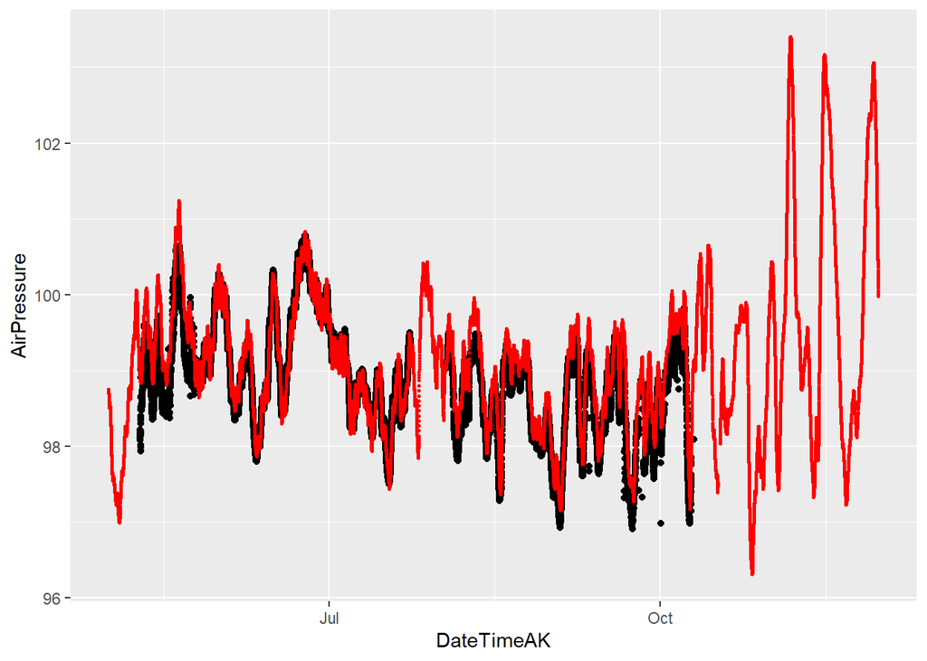

```r
# Compare with NEON converted air pressure.
moos.atmo.2022 %>% filter(AirPressure > 96.8) %>% ggplot(aes(x = DateTimeAK, y = AirPressure)) +
  geom_point() + geom_point(data = Air_combo, aes(DateTimeAK, AirPressureCorrectedMOOS), color = "red", size = 0.5)
```

Looks like we have to use the corrected pressure to get what we want for our rating curves.

We will only use pressure transducer 2 at Moose because it is more complete.

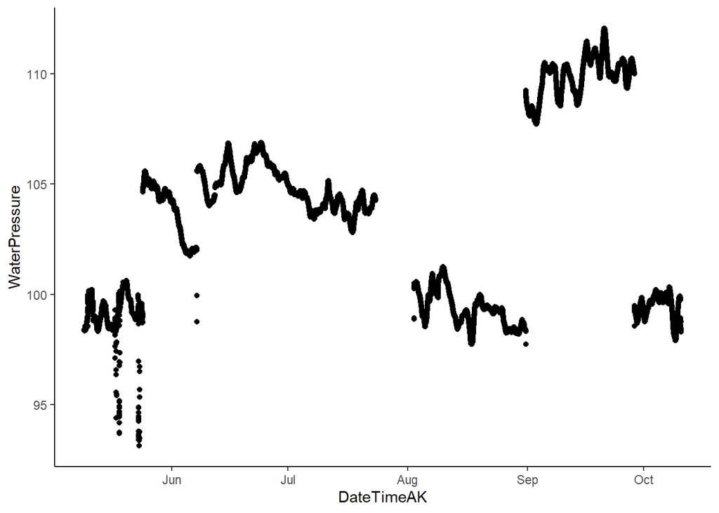

```r
moos.stream.two.2022 %>%
  ggplot(aes(x = DateTimeAK, y = WaterPressure)) +
  geom_point() +
  theme_classic()
```

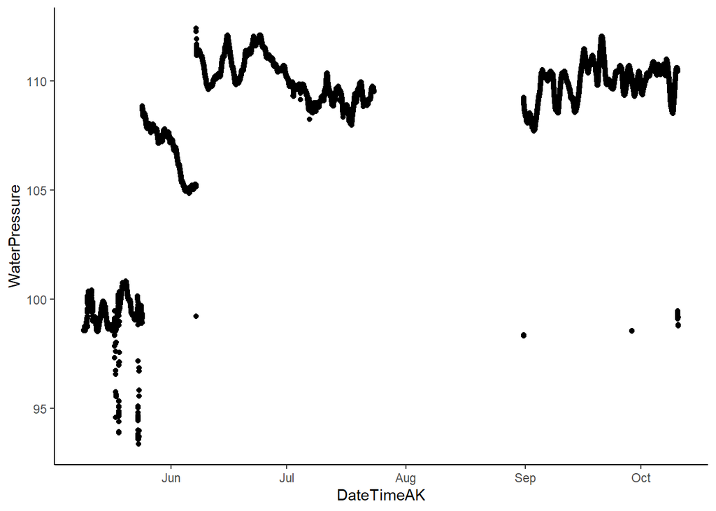

```r
ggplot(moos.stream.one.2022, aes(x = DateTimeAK, y = WaterPressure)) +
  geom_point() +
  theme_classic()
```

This is PT2 that has the step changes due to the cleaning and then it has a gap at the end of July to beginning of August was because the memory filled up.

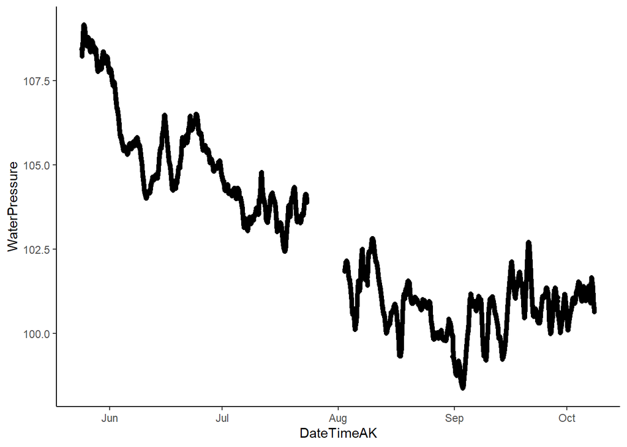

```r
# adjusting/cleaning moos.stream.two

moos.stream.two.2022 <- moos.stream.two.2022 %>%
  mutate(across(c(WaterPressure),
                ~ifelse(DateTimeAK <= "2022-05-25" & WaterPressure < 103, NA, .))) # PT wasnt placed into the stream until 5/25?

moos.stream.two.2022 <- moos.stream.two.2022 %>%
  mutate(across(c(WaterPressure),
                ~ifelse(DateTimeAK >= "2022-06-01" & DateTimeAK <= "2022-07-01" & WaterPressure < 101, NA, .))) %>% filter(WaterPressure > 90)

# shifting the step change
# 6/7 @ 14:05 we cleaned the PVC housing so we are shifting the previous data up to match after the cleaning
moos.stream.two.2022 <- moos.stream.two.2022 %>%
  mutate(across(c(WaterPressure),
                ~ifelse(DateTimeAK <= "2022-06-07 14:05:00", WaterPressure + 3.573, .)))

# shifting the step change
moos.stream.two.2022 <- moos.stream.two.2022 %>%
  mutate(across(c(WaterPressure),
                ~ifelse(DateTimeAK >= "2022-08-31 13:55:00" & DateTimeAK <= "2022-09-28 14:00:00", WaterPressure - 10.918, .)))

## Bring the last chunk up half way?
moos.stream.two.2022 <- moos.stream.two.2022 %>%
  mutate(across(c(WaterPressure),
                ~ifelse(DateTimeAK > "2022-08-01", WaterPressure + 3.897/2, .)))
#moos.stream.two.2022[17192, 2] - moos.stream.two.2022[17211, 2] # 3.897


moos.stream.two.2022 <- moos.stream.two.2022 %>% filter(DateTimeAK < "2022-07-31" | DateTimeAK > "2022-08-02 16:45:00") %>% filter(DateTimeAK <= "2022-10-08 08:15:00")

# shifting small step change
moos.stream.two.2022 <- moos.stream.two.2022 %>%
  mutate(across(c(WaterPressure),
                ~ifelse(DateTimeAK >= "2022-06-12 04:50", WaterPressure - 0.365, .)))
#moos.stream.two.2022[5240, 2] - moos.stream.two.2022[5241, 2] # 0.365
moos.stream.two.2022 <- moos.stream.two.2022 %>%
  mutate(across(c(WaterPressure),
                ~ifelse(DateTimeAK >= "2022-06-12" & DateTimeAK < "2022-06-13" & WaterPressure < 104.2, NA, .)))


moos.stream.two.2022 <- moos.stream.two.2022 %>%
  mutate(across(c(WaterPressure),
                ~ifelse(DateTimeAK >= "2022-09-28 14:20", WaterPressure - 0.248, .)))

moos.stream.two.2022 <- moos.stream.two.2022 %>%
  mutate(across(c(WaterPressure),
                ~ifelse(DateTimeAK >= "2022-09-28" & DateTimeAK <= "2022-09-28 17:00" & WaterPressure < 100.2, NA, .))) %>% filter(WaterPressure > 90)

moos.stream.two.2022 <- moos.stream.two.2022 %>%
  mutate(across(c(WaterPressure),
                ~ifelse(DateTimeAK >= "2022-09-28 12:00" & DateTimeAK <= "2022-09-28 15:00" & WaterPressure < 100.3, NA, .)))


moos.stream.two.2022 %>%  #filter(DateTimeAK > "2022-09-28 12:00") %>%
  #filter(DateTimeAK > "2022-09-25" & DateTimeAK < "2022-10-01") %>%
  ggplot(aes(x = DateTimeAK, y = WaterPressure)) +
  geom_point() +
  theme_classic()
```

This looks much better. Lets shift the beginning section down.

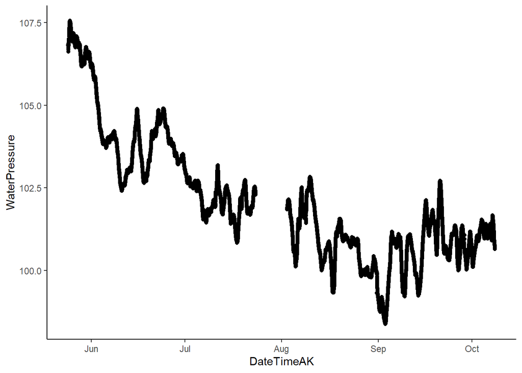

```r
# Shift
moos.stream.two.2022 <- moos.stream.two.2022 %>%
  mutate(across(c(WaterPressure),
                ~ifelse(DateTimeAK <= "2022-07-28", WaterPressure - 1.6, .))) # 1.6 was a guess

moos.stream.two.2022 %>%  #filter(DateTimeAK > "2022-09-28 12:00") %>%
  #filter(DateTimeAK > "2022-09-28 12:00:00" & DateTimeAK < "2022-09-29") %>%
  ggplot(aes(x = DateTimeAK, y = WaterPressure)) +
  geom_point() +
  theme_classic()
```

```r
## Combine water and air pressure
# Final water pressure
moos.final.pressure.2022 <- moos.stream.two.2022


moos.final.pressure.2022 <- moos.final.pressure.2022[,-c(3,5,7)] # removing columns that are unnecessary. I only need both water pressures and mean pressure with a DateTime column


#eielson.atmo.2022 <- eielson.atmo.2022[,-c(1,3)] # i dont need site, Temp and sea_level_pressure column

#eielson.atmo.2022.compare <-  eielson.atmo.2022.compare[ , -which(names(eielson.atmo.2022.compare) %in% c("Site","TempC", #"sea_level_pressure", "AirPressure", "mmHG", #"mmHGcorrectedMOOS","mmHGcorrectedPOKE","mmHGcorrectedSTRT","mmHGcorrectedFRCH","mmHGcorrectedVAUL"))] # removing columns I do not need

# Fill gap during end of July for our pressure data with Eielson data
#atmo.pt.2022.1$moos.combo <- ifelse(atmo.pt.2022.1$DateTimeAK > "2022-07-23 17:15:00" & atmo.pt.2022.1$DateTimeAK < "2022-08-02 #17:00:00", atmo.pt.2022.1$AirPressureCorrectedMOOS, atmo.pt.2022.1$AirPressure.y)

# Remove outliers
#atmo.pt.2022.1 <- atmo.pt.2022.1 %>%
#  mutate(across(c(moos.combo),
#                ~ifelse(DateTimeAK >= "2022-09-10" & DateTimeAK <= "2022-09-11" & moos.combo < 98.5, NA, .)))

#atmo.pt.2022.1 %>% filter(DateTimeAK > "2022-05-15") %>%
  #filter(DateTimeAK > "2022-06-01" & DateTimeAK < "2022-09-01") %>%
# ggplot(aes(DateTimeAK, AirPressureCorrectedMOOS)) + geom_point() +
#  geom_point(aes(DateTimeAK, AirPressure.x))#+ geom_vline(xintercept = as.POSIXct("2022-09-10")) + geom_vline(xintercept = as.POSIXct("2022-09-12"))
```

Our Moose air pressure data is so messy - we will use NEON’s data.

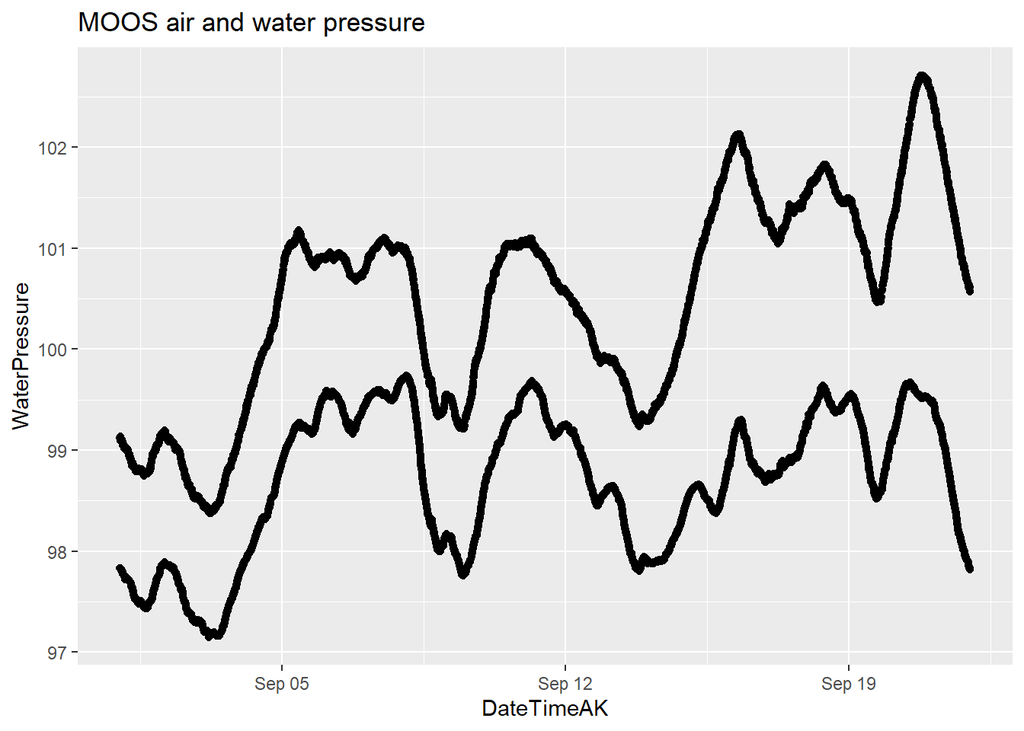

```r
#join the atmospheric and water pressure together

MOOS.2022 <- full_join(moos.final.pressure.2022, Air_combo, by = "DateTimeAK") %>% dplyr::select("DateTimeAK", "AirPressureCorrectedMOOS", "WaterPressure")

# Fill gaps in data
DateTimeFill <- data.frame(DateTimeAK = seq(ymd_hm("2022-05-25 00:00", tz = "America/Anchorage"),ymd_hm("2022-10-08 08:15", tz = "America/Anchorage"), by = '15 mins'))
MOOS.2022 <- full_join(MOOS.2022, DateTimeFill)
MOOS.2022 <- MOOS.2022[order(MOOS.2022$DateTimeAK),]
MOOS.2022 <- na_kalman(MOOS.2022, maxgap = 10)

MOOS.2022 %>% filter(DateTimeAK >= "2022-05-25" & DateTimeAK <= "2022-10-08") %>%
  filter(DateTimeAK > "2022-09-01" & DateTimeAK < "2022-09-22") %>%
  ggplot(aes(DateTimeAK, WaterPressure)) + geom_point() + geom_point(aes(DateTimeAK, AirPressureCorrectedMOOS)) + #geom_vline (xintercept = as.POSIXct("2022-09-20 20:00:00"))
ggtitle("MOOS air and water pressure")
```

```r
# Water pressure - atmospheric pressure
 MOOS.2022$difference <- MOOS.2022$WaterPressure - MOOS.2022$AirPressureCorrectedMOOS

# Time checks
MOOS.2022 <- MOOS.2022 %>% group_by(DateTimeAK) %>% summarise( difference = mean( difference))
any(duplicated(MOOS.2022$DateTimeAK))
```

```
## [1] FALSE
```

```r
MOOS.2022$diff <- MOOS.2022$DateTimeAK - lag(MOOS.2022$DateTimeAK)
unique(MOOS.2022$diff)
```

```
##  [1]  NA   5  10  15 815  80  70 125 110 100  65
```

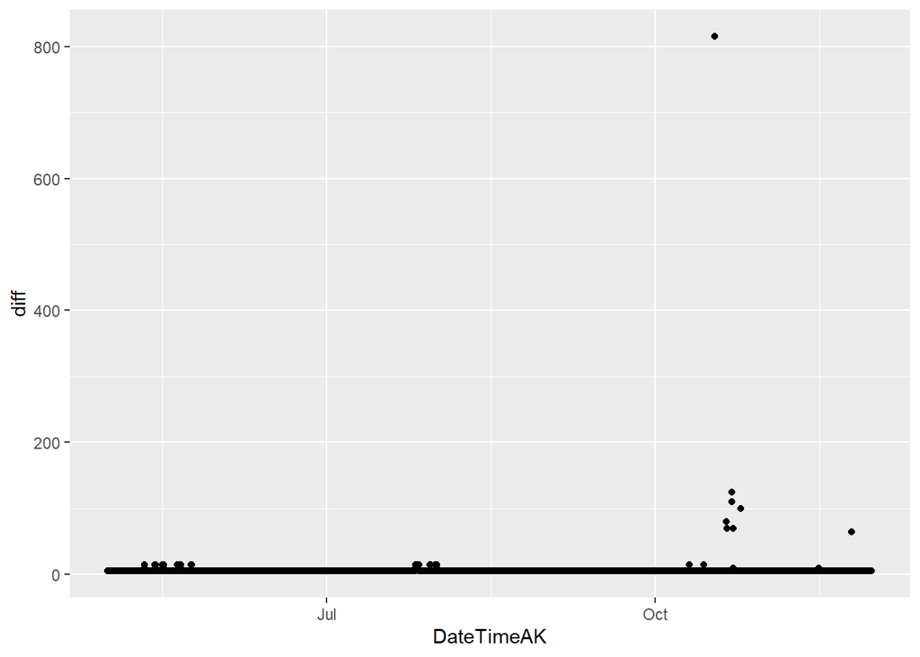

```r
MOOS.2022 %>% #filter(diff < 20) %>%
  ggplot(aes(DateTimeAK, diff)) + geom_point()
```

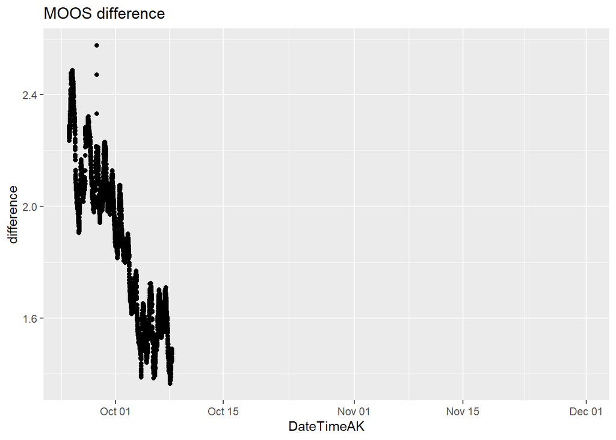

```r
# Plot difference
MOOS.2022 %>% #filter(DateTimeAK > "2022-10-08") %>%
  filter(DateTimeAK > "2022-09-25") %>%
  ggplot(aes(DateTimeAK, difference)) + geom_point() +
  ggtitle("MOOS difference")
```

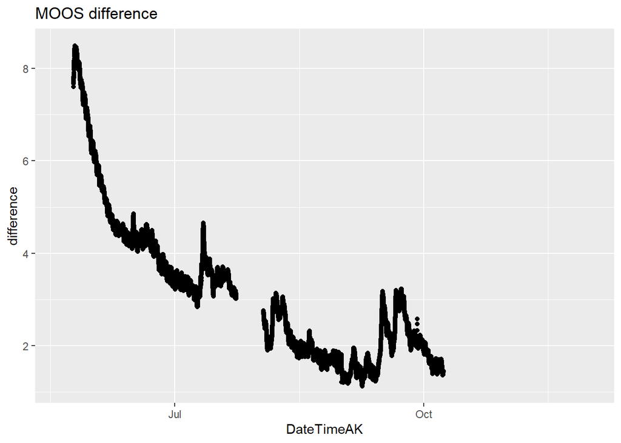

```r
# Clean the late season points
MOOS.2022 <- MOOS.2022 %>%
  mutate(across(c(difference),
                ~ifelse(DateTimeAK >= "2022-10-08" & difference > 1.45, NA, .)))

MOOS.2022$difference <- na_kalman(MOOS.2022$difference, maxgap = 10)

# Plot difference
MOOS.2022 %>% filter(DateTimeAK > "2022-05-20") %>%
  ggplot(aes(DateTimeAK, difference)) + geom_point() +
  ggtitle("MOOS difference")
```

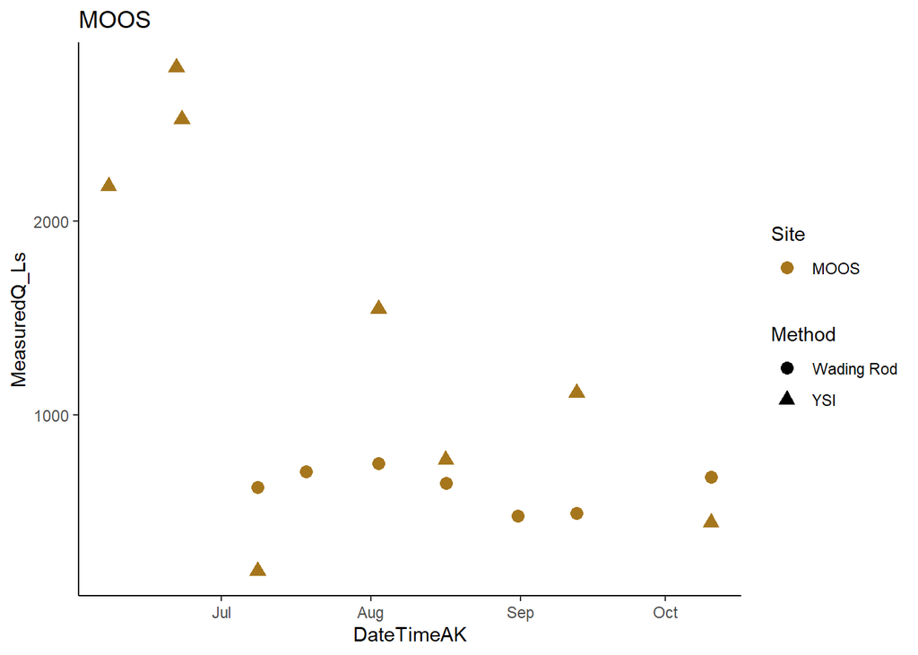

```r
### Plot MOOS measured Q
QSummary.MO.2022 <- QSummary.2022 %>% filter(Site =="MOOS")

ggplot(QSummary.MO.2022) +
  geom_point(aes(x = DateTimeAK, y = MeasuredQ_Ls, shape = Method, color = Site), size=3) +
  theme_classic() +
  scale_color_manual(values=c("#A6761D")) +
  ggtitle("MOOS")
```

```r
# trying to merge by nearest date if we have an offset point
MOOS.2022.dt <- setDT(MOOS.2022)
MOOS.2022.dt <- subset(MOOS.2022.dt, DateTimeAK < "2022-10-19 14:00:00") %>% na.omit()# removing rows that had dates corresponding to end of record that messed up the rolling nearest function
QSummary.MO.2022.dt <- QSummary.MO.2022

Moose1comb.2022 <- MOOS.2022.dt[QSummary.MO.2022.dt, on = "DateTimeAK", roll = 'nearest']
```

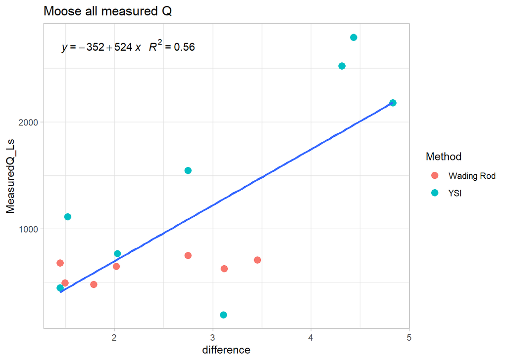

```r
# plot rating curve
moos.formula = y~x

ggplot(aes(x = difference, y = MeasuredQ_Ls), data = Moose1comb.2022) +
  geom_point(aes(color = Method), size = 3) +
  geom_smooth(method = "lm", se=FALSE, formula = moos.formula) +
  stat_poly_eq(formula = moos.formula,
               aes(label = paste(..eq.label.., ..rr.label.., sep = "~~~")),
               parse = TRUE) +
  theme_light() +
  ggtitle("Moose all measured Q")
```

I will remove two YSI points.

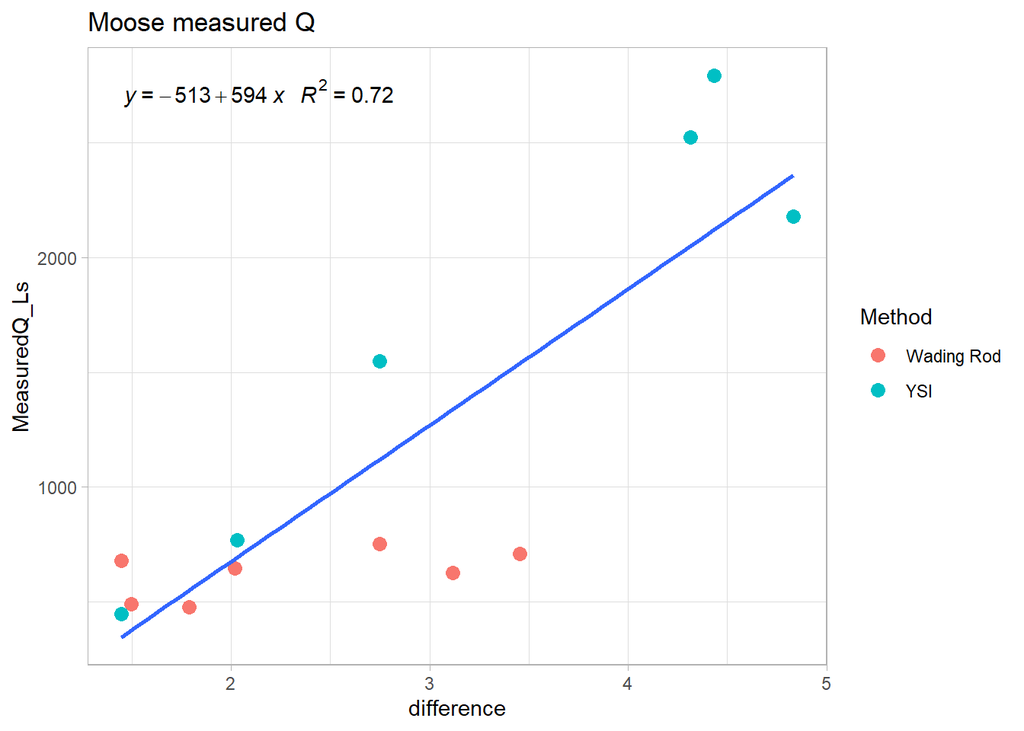

```r
# Remove outlier Q points
Moose1comb.2022.2 <- Moose1comb.2022 %>% filter(difference > 2 | MeasuredQ_Ls < 1000) %>% filter(MeasuredQ_Ls > 300)


# plot rating curve
moos.formula = y~ x

ggplot(aes(x = difference, y = MeasuredQ_Ls), data = Moose1comb.2022.2) +
  geom_point(aes(color = Method), size = 3) +
  geom_smooth(method = "lm", se=FALSE, formula = moos.formula) +
  stat_poly_eq(formula = moos.formula,
               aes(label = paste(..eq.label.., ..rr.label.., sep = "~~~")),
               parse = TRUE) +
  theme_light() +
  ggtitle("Moose measured Q")
```

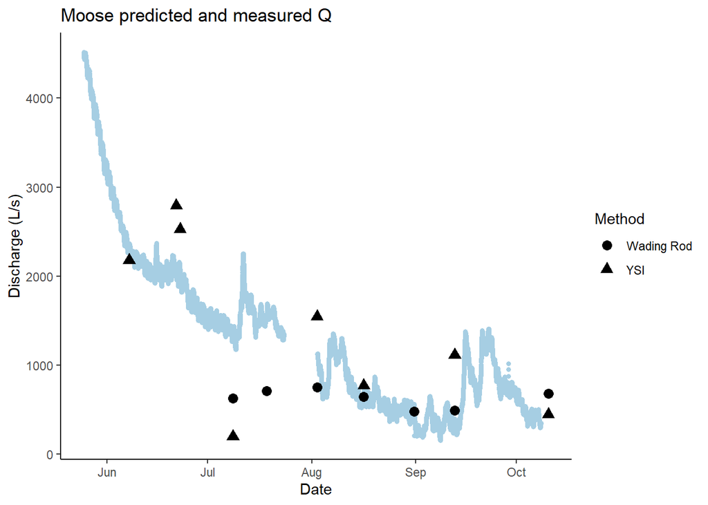

```r
## Predict MOOS Q

MOOS1.lm.2022 <- lm(Moose1comb.2022.2$MeasuredQ_Ls ~ Moose1comb.2022.2$difference)

MOOS.2022.dt$pred.moos1.Q <- coef(MOOS1.lm.2022)[2] * MOOS.2022.dt$difference+ coef(MOOS1.lm.2022)[1]

MOOS.2022.dt <- MOOS.2022.dt %>% dplyr::select(DateTimeAK, pred.moos1.Q) %>% filter(DateTimeAK >= "2022-05-25 00:05" & DateTimeAK <= "2022-10-08 08:15:00")
MOOS.2022.dt <- na_kalman(MOOS.2022.dt, maxgap = 10)

MOOS.2022.dt %>% na.omit() %>% ggplot(aes(x = DateTimeAK, y = pred.moos1.Q)) +
  geom_point(color="#A6CEE3", size=1.25) +
  geom_point(data = Moose1comb.2022, aes(x = DateTimeAK, y = MeasuredQ_Ls, shape = Method), size=3) +
  theme_classic() +
  ggtitle("Moose predicted and measured Q") +
  xlab("Date") +
  ylab("Discharge (L/s)")
```

### POKE

```r
poke.stream.one.2022.url <- "https://docs.google.com/spreadsheets/d/e/2PACX-1vR8p1pdbkQBMo54XaZinGwxyzojCnlkXeZid3EFvmt9v31PFvpsa1DlWClj8aG0kkJIuU57WXl-cq7Q/pub?output=csv"
poke.stream.two.2022.url <- "https://docs.google.com/spreadsheets/d/e/2PACX-1vR-wJjf3rO8eC7bMpQZgwqFLHFQpf5qCInyWtUF1PqaCB8Z_EoM1cTHRUmWypjftREIx1rP0V6zYJxL/pub?output=csv"

# load in url
poke.stream.one.2022 <- read.csv(url(poke.stream.one.2022.url), skip = 1)
poke.stream.two.2022 <- read.csv(url(poke.stream.two.2022.url), skip = 1)

# cleaning df to be able to interpret and merge
poke.stream.one.2022 <- poke.stream.one.2022[, -c(5:18)] # removing columns that arent date/abs pressure and temp

poke.stream.two.2022 <- poke.stream.two.2022[, -c(5:9)] # removing columns that arent date/abs pressure and temp

# changing to AK time (It reads in as GMT but it is actually AKST )
poke.stream.one.2022$DateTimeAK <- mdy_hms(poke.stream.one.2022$Date.Time..GMT.08.00)

poke.stream.two.2022$DateTimeAK <- mdy_hms(poke.stream.two.2022$Date.Time..GMT.08.00)

poke.stream.two.2022$DateTimeAK <- force_tz(poke.stream.two.2022$DateTimeAK, tzone = "America/Anchorage")

poke.stream.one.2022$DateTimeAK <- force_tz(poke.stream.one.2022$DateTimeAK, tzone = "America/Anchorage")

# round date to 5 minute intervals
poke.stream.one.2022$DateTimeAK <- lubridate::round_date(poke.stream.one.2022$DateTimeAK, "5 minutes")
poke.stream.two.2022$DateTimeAK <- lubridate::round_date(poke.stream.two.2022$DateTimeAK, "5 minutes")

# cleaning off original datetime
poke.stream.one.2022 <- poke.stream.one.2022[, -c(2)] # removing columns that aren't date/abs pressure and temp
poke.stream.two.2022 <- poke.stream.two.2022[, -c(2)] # removing columns that arent


names(poke.stream.one.2022) <- c("Site", "WaterPressure", "TempC", "DateTimeAK")
names(poke.stream.two.2022) <- c("Site", "WaterPressure", "TempC", "DateTimeAK")
```

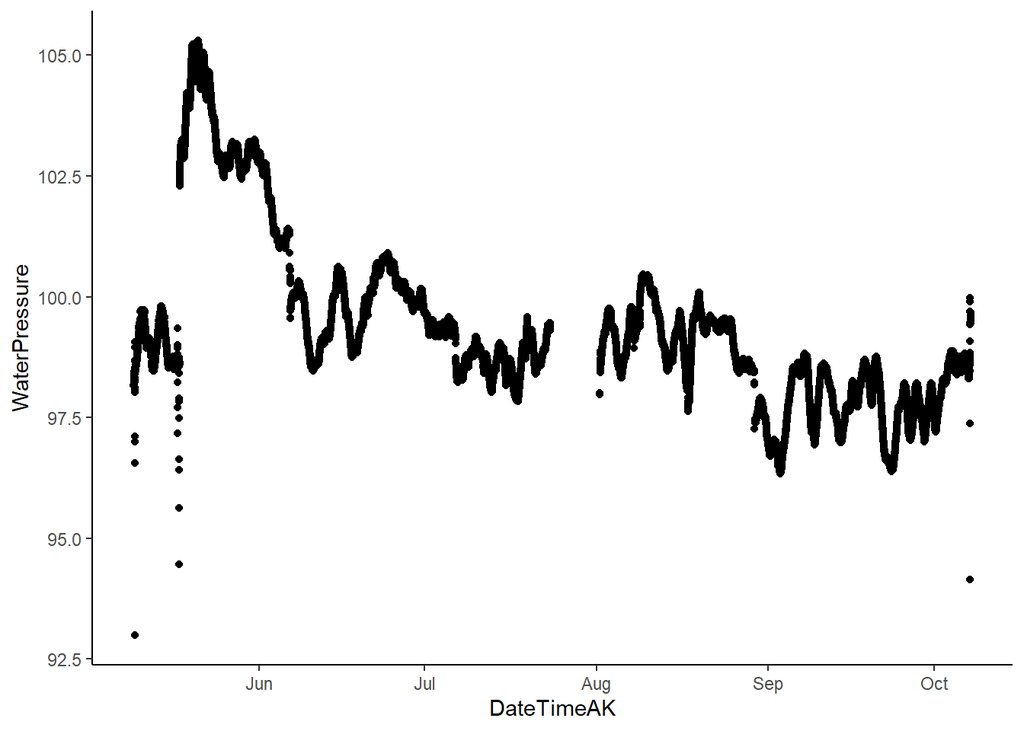

```r
ggplot(poke.stream.one.2022, aes(x = DateTimeAK, y = WaterPressure))+
  geom_point() +
  theme_classic()
```

This is PT1….step change is air pressure and then placed in the stream. Let me clip that out

```r
#poke.stream.one.2022.b <- poke.stream.one.2022
#poke.stream.one.2022 <- poke.stream.one.2022.b

#adjusting/cleaning poke.stream.one
poke.stream.one.2022 <- poke.stream.one.2022 %>%
  mutate(across(c(WaterPressure),
                ~ifelse(DateTimeAK >= "2022-05-09" & DateTimeAK <= "2022-05-18", NA, .))) # PT wasnt placed into the stream until 5/17

poke.stream.one.2022 <- poke.stream.one.2022 %>%
  mutate(across(c(WaterPressure),
                ~ifelse(DateTimeAK >= "2022-08-27" & DateTimeAK <= "2022-08-31" & WaterPressure < 98.3, NA, .))) %>% filter( DateTimeAK <= "2022-10-07 15:30:00")

poke.stream.one.2022 <- poke.stream.one.2022 %>%
  mutate(across(c(WaterPressure),
                ~ifelse(DateTimeAK >= "2022-10-05" & DateTimeAK <= "2022-10-07" & WaterPressure < 98, NA, .)))

poke.stream.one.2022 <- poke.stream.one.2022 %>%
  mutate(across(c(WaterPressure),
                ~ifelse(DateTimeAK >= "2022-10-05" & DateTimeAK <= "2022-10-07" & WaterPressure < 98, NA, .))) %>%
  filter(DateTimeAK > "2022-08-01 16:15:00" | DateTimeAK < "2022-08-01 00:00:00") %>%
  filter(DateTimeAK != "2022-08-07 19:00:00")

# shifting small step change
poke.2.before <- poke.stream.one.2022[c(1:16756), ]
poke.2.after <- poke.stream.one.2022[c(16758:40000), ]
poke.stream.one.2022[16756, 2] - poke.stream.one.2022[16758, 2] # 0.39
```

```
## [1] 0.39
```

```r
poke.2.after$WaterPressure <- poke.2.after[, 2] + 0.39
poke.stream.one.2022 <- full_join(poke.2.before, poke.2.after)

# shifting larger step change
poke.1.before2 <- poke.stream.one.2022[c(1:8125), ]
poke.1.after2 <- poke.stream.one.2022[c(8150:40000), ]
poke.stream.one.2022[8150, 2] - poke.stream.one.2022[8125, 2] # 1.55
```

```
## [1] -1.55
```

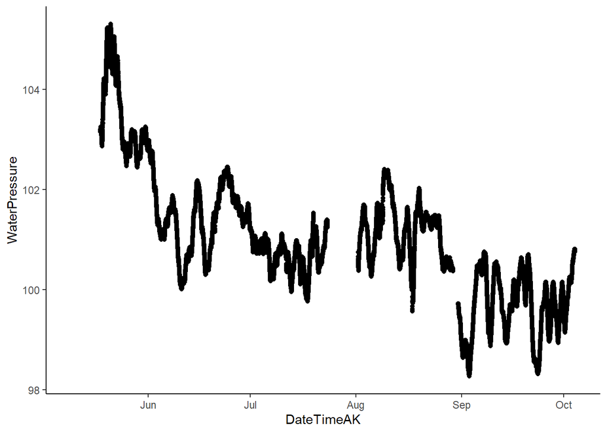

```r
poke.1.after2$WaterPressure <- poke.1.after2[, 2] + 1.55
poke.stream.one.2022 <- full_join(poke.1.before2, poke.1.after2)


poke.stream.one.2022 %>% #filter(DateTimeAK > "2022-08-07" & DateTimeAK < "2022-08-15") %>%
  ggplot(aes(x = DateTimeAK, y = WaterPressure))+
  geom_point() +
  theme_classic()
```

Clean PT2

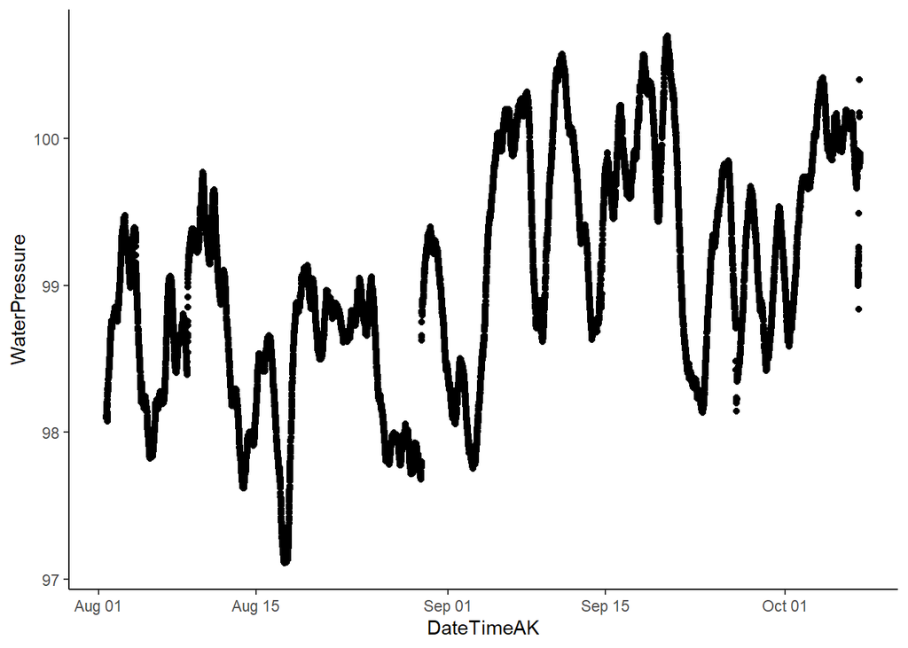

```r
poke.stream.two.2022 <- poke.stream.two.2022 %>%
  mutate(across(c(WaterPressure),
                ~ifelse(DateTimeAK >= "2022-09-17" & WaterPressure < 98, NA, .))) %>%
  filter(DateTimeAK <= "2022-10-07 15:35:00")

poke.stream.two.2022 %>% ggplot(aes(x = DateTimeAK, y = WaterPressure))+
  geom_point() +
  theme_classic()
```

This is PT2…we only have data from 8/1 because of our musical chairs situation. We got two PTs back from onset so we deployed a second PT at POKE.

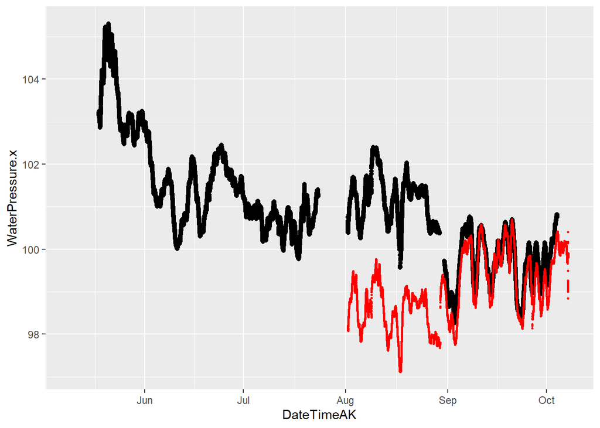

```r
# merge to one
poke.final.pressure.2022 <- full_join(poke.stream.one.2022, poke.stream.two.2022, by = c("DateTimeAK"))


poke.final.pressure.2022 %>% ggplot() + geom_point(aes(DateTimeAK, WaterPressure.x)) + geom_point(aes(DateTimeAK, WaterPressure.y), color = "red", cex = 0.5)
```

It looks like we should use PT1 before August 1st (black) and PT2 after August 1st (red).

```r
## Use PT1 before August 1st and PT2 after August 1st
# Shift PT2 up to match August PT1
poke.final.pressure.2022 %>% filter(DateTimeAK > "2022-08-01" & DateTimeAK < "2022-08-15") %>% summarise(mean(WaterPressure.x - WaterPressure.y)) #2.62398
```

| mean(WaterPressure.x - WaterPressure.y) |
| --- |
| NA |

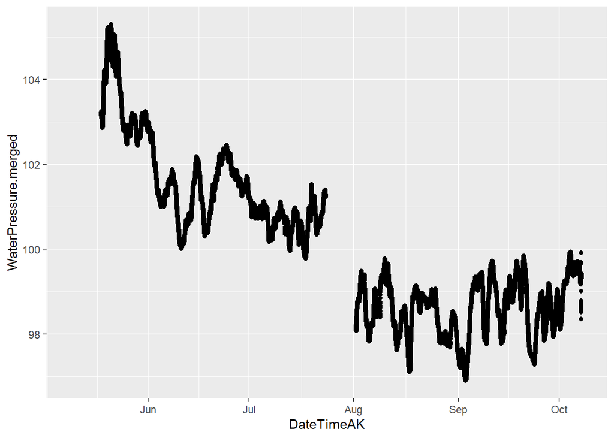

```r
poke.final.pressure.2022 <- poke.final.pressure.2022 %>%
  mutate(WaterPressure.merged = ifelse(DateTimeAK <= "2022-08-01", WaterPressure.x, WaterPressure.y)) %>%
  dplyr::select("DateTimeAK", "WaterPressure.merged")

# September step change

poke.before.2 <- poke.final.pressure.2022 %>% filter(DateTimeAK <= "2022-09-26 14:40" )
poke.after.2 <- poke.final.pressure.2022 %>% filter(DateTimeAK >= "2022-09-26 16:35")
poke.after.2$WaterPressure.merged <- poke.after.2$WaterPressure.merged + 0.374
poke.final.pressure.2022 <- rbind(poke.before.2, poke.after.2)

# End of August step change... move after data down all the way?
poke.before <- poke.final.pressure.2022 %>% filter(DateTimeAK <= "2022-08-29 14:40")
poke.after <- poke.final.pressure.2022 %>% filter(DateTimeAK >= "2022-08-29 16:35:00")
poke.after$WaterPressure.merged <- poke.after$WaterPressure.merged - 0.858
poke.final.pressure.2022 <- rbind(poke.before, poke.after)


poke.final.pressure.2022 %>% #filter(DateTimeAK > "2022-10-01 14:40" & DateTimeAK < "2022-10-27") %>%
  ggplot() + geom_point(aes(DateTimeAK, WaterPressure.merged))
```

Shift after gap?

```r
# Join the two atmospheric and water pressure together

POKE.2022 <- full_join(Air_combo, poke.final.pressure.2022, by = "DateTimeAK") %>%
  dplyr::select(DateTimeAK, AirPressureCorrectedPOKE, WaterPressure.merged)


## Bring the last chunk up half way?
101.250-98.134
```

```
## [1] 3.116
```

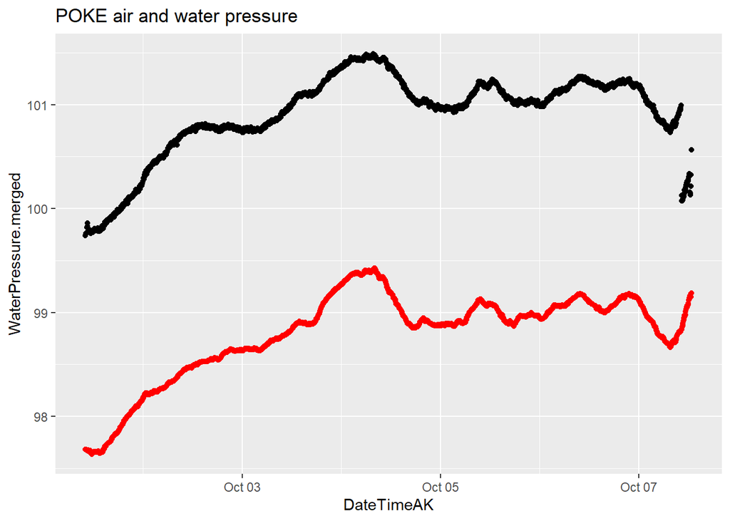

```r
POKE.2022 <- POKE.2022 %>%
 mutate(across(c(WaterPressure.merged),
                ~ifelse(DateTimeAK > "2022-07-30", WaterPressure.merged + 3.116*.5, .)))

# Remove end outliers
POKE.2022 <- POKE.2022 %>% filter(DateTimeAK <= "2022-10-07 12:50:00")


# Water pressure - atmospheric pressure
DateTimeFill <- data.frame(DateTimeAK = seq(ymd_hm("
2022-05-18 00:00", tz = "America/Anchorage"),ymd_hm("2022-10-07 12:50", tz = "America/Anchorage"), by = '15 mins'))
POKE.2022 <- full_join(POKE.2022, DateTimeFill, by = "DateTimeAK")
POKE.2022 <- POKE.2022[order(POKE.2022$DateTimeAK),]
POKE.2022$WaterPressure.merged <- na_kalman(POKE.2022$WaterPressure.merged, maxgap = 10)

POKE.2022$difference <- POKE.2022$WaterPressure.merged - POKE.2022$AirPressureCorrectedPOKE


# Plot air and water pressure

POKE.2022 %>% filter(DateTimeAK >"2022-10-01 10:00:00" & DateTimeAK < "2022-10-30 20:00:00") %>%
  filter(DateTimeAK > "2022-05-25") %>%
  ggplot(aes(DateTimeAK, WaterPressure.merged)) + geom_point() + geom_point(aes(DateTimeAK, AirPressureCorrectedPOKE), color = "red") + #geom_point(aes(color = Method, x = DateTimeAK, y = WaterPressure.merged), data = Poker1comb.2022[c(19,20),])
  ggtitle("POKE air and water pressure")
```

```r
# Remove duplicated time steps
POKE.2022 <- POKE.2022 %>% group_by(DateTimeAK) %>% summarise( difference = mean( difference))
any(duplicated(POKE.2022$DateTimeAK))
```

```
## [1] FALSE
```

```r
# Check time step intervals
POKE.2022$diff <- POKE.2022$DateTimeAK - lag(POKE.2022$DateTimeAK)
unique(POKE.2022$diff)
```

```
## [1] NA  5 10 15
```

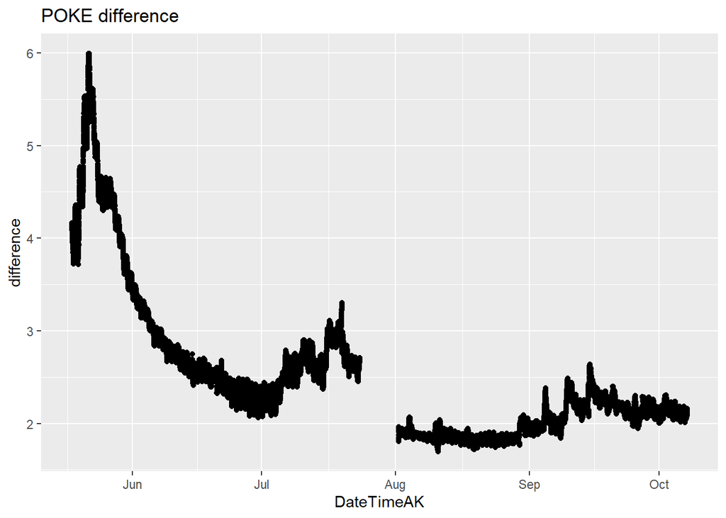

```r
# Remove end outliers
POKE.2022 <- POKE.2022 %>% filter(difference > 1.6)

# Plot difference
POKE.2022 %>% filter(DateTimeAK > "2022-05-15") %>%
  ggplot(aes(DateTimeAK, difference)) + geom_point() +
  ggtitle("POKE difference")
```

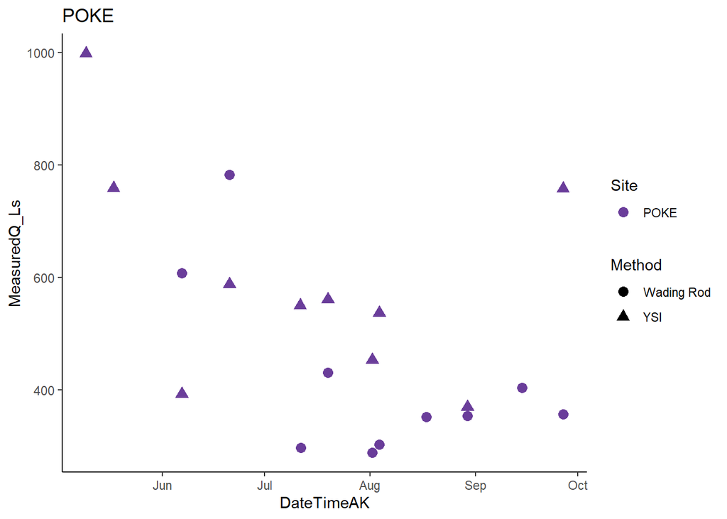

```r
### Filter POKE ###
QSummary.PO.2022 <- QSummary.2022 %>% filter(Site =="POKE")

ggplot(QSummary.PO.2022) +
  geom_point(aes(x = DateTimeAK, y = MeasuredQ_Ls, shape = Method, color = Site), size=3) +
  theme_classic() +
  scale_color_manual(values=c("#6A3D9A")) +
  ggtitle("POKE")
```

```r
# Merge by nearest date if we have an offset point
POKE.2022.dt <- setDT(POKE.2022) %>% filter(!difference %in% NA)
QSummary.PO.2022.dt <- QSummary.PO.2022 %>% filter(DateTimeAK > "2022-05-17")

Poker1comb.2022 <- POKE.2022.dt[QSummary.PO.2022.dt, on = "DateTimeAK", roll = 'nearest']
```

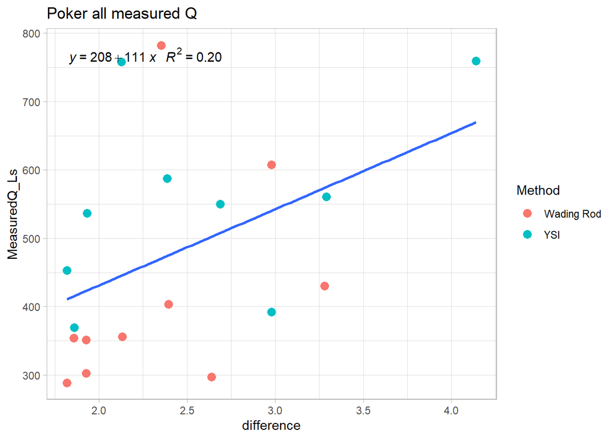

```r
### Rating Curve ###
poke.formula <- y ~ x
ggplot(aes(x = difference, y = MeasuredQ_Ls), data = Poker1comb.2022) +
  geom_point(aes(color = Method), size = 3) +
  geom_smooth(method = "lm", se=FALSE, formula = poke.formula) +
  stat_poly_eq(formula = poke.formula,
               aes(label = paste(..eq.label.., ..rr.label.., sep = "~~~")),
               parse = TRUE) +
  theme_light() +
  ggtitle("Poker all measured Q")
```

I am not sure what is going on here. I plotted every single pressure point that is matched with a Q measurement and they all look reasonable/are not outliers.